# Analysis

```r
tdata <- read_csv("exp_data.csv")
```

```r
# Exclude subjects who failed the control questions
tdata <- subset(tdata, confirmations_correct == "correct")
tdata <- subset(tdata, intro_check_correct == "correct")
tdata <- subset(tdata, learning_check_correct == "correct")
tdata <- subset(tdata, learn_check_structure_correct == "correct")
tdata <- subset(tdata, timing_check_correct == "correct")
```

```r
table(tdata$structure, tdata$first_object)
```

```
##
##            left right
##   stable     25    25
##   unstable   25    25
```

# 1 Subject demographics

```r
# demographics

min(tdata$age)
```

```
## [1] 19
```

```r
max(tdata$age)
```

```
## [1] 83
```

```r
mean(tdata$age)
```

```
## [1] 39.02
```

```r
sd(tdata$age)
```

```
## [1] 15.52253
```

```r
# 1 = male, 2 = female, 3 = other
table(tdata$gender)
```

```
##
##              1: male            2: female        3: non-binary
##                   46                   51                    2
## 4: prefer not to say
##                    1
```

1 = male, 2 = female, 3 = non-binary, 4 = prefer not to say

# 2 Data preparations

Factorize:

```r
tdata$structure <- factor(tdata$structure, levels = c("stable", "unstable"), labels = c("one-shot", "demarcation"))
```

Relabel rating columns for red and yellow entity according to “first object” (so that they are called first_obj_rating and second_obj_rating):

```r
left_first <- subset(tdata, first_object == "left")
colnames(left_first)[11] ="first_obj_caused_rating"
colnames(left_first)[12] ="second_obj_caused_rating"
colnames(left_first)[13] ="first_obj_sustained_rating"
colnames(left_first)[14] ="second_obj_sustained_rating"

right_first <- subset(tdata, first_object == "right")
colnames(right_first)[12] ="first_obj_caused_rating"
colnames(right_first)[11] ="second_obj_caused_rating"
colnames(right_first)[14] ="first_obj_sustained_rating"
colnames(right_first)[13] ="second_obj_sustained_rating"

right_first <- right_first[c("subj_code", "condition", "desktop_conf", "attent_conf", "intro_check",
                             "structure", "first_object", "learn_check_left", "learn_check_right", "learn_check_structure",
                             "first_obj_caused_rating", "second_obj_caused_rating", "first_obj_sustained_rating", "second_obj_sustained_rating",
                             "timing_check", "recorded_at",
                             "age", "gender", "tech_issues",
                             "confirmations_correct", "intro_check_correct",
                             "learning_check_left_correct", "learning_check_right_correct", "learning_check_correct",
                             "learn_check_structure_correct", "timing_check_correct")]


names(left_first) %in% names(right_first)
```

```
##  [1] TRUE TRUE TRUE TRUE TRUE TRUE TRUE TRUE TRUE TRUE TRUE TRUE TRUE TRUE TRUE
## [16] TRUE TRUE TRUE TRUE TRUE TRUE TRUE TRUE TRUE TRUE TRUE
```

```r
tdata <- rbind(left_first, right_first)
```

Make a subset containing only the columns relevant for analyses and turn into long format:

```r
# Subset:
tdata_sub <- subset(tdata, select = c("subj_code","structure","first_obj_caused_rating", "second_obj_caused_rating",
                                      "first_obj_sustained_rating", "second_obj_sustained_rating"))

# into long format:
library(tidyr)
tdata_long <- gather(tdata_sub, entity, rating, 3:6)


# factorize entity
tdata_long$entity <- factor(tdata_long$entity, levels = c("first_obj_caused_rating", "second_obj_caused_rating",
                                                          "first_obj_sustained_rating", "second_obj_sustained_rating"),
                            labels = c("first \ntriggered", "second \ntriggered","first \nsustained", "second \nsustained"))
```

# 3 Graphs and summaries

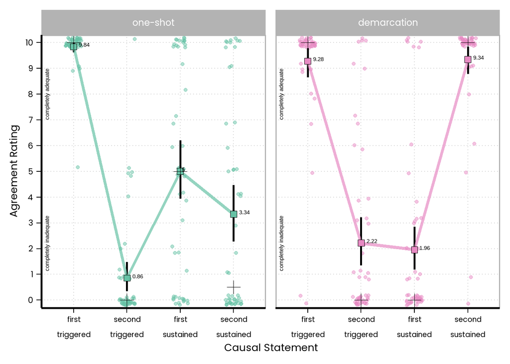

```r
myTheme <- theme(plot.title = element_text(face="bold", size = 22),
        axis.title.x = element_text(size = 20),
        axis.title.y = element_text(size = 20),
        axis.text.x = element_text(size = 14, angle = 0),
        axis.text.y = element_text(size = 16, angle = 0),
        legend.text = element_text(size = 18),
        legend.title = element_text(face = "bold", size = 18),
        strip.text.x = element_text(size = 18),
        panel.grid.major = element_blank(),
        panel.grid.minor = element_blank(),
        panel.background = element_blank(),
        axis.line.x = element_line(colour = "black"),
        axis.line.y = element_line(colour = "black"),
        axis.text = element_text(colour ="black"),
        axis.ticks = element_line(colour ="black"))


tdata_sub <- tdata_long


library(see)
## first, turn sID into a factor
tdata_sub$subj_code <- factor(tdata_sub$subj_code)

pd <- position_dodge(width = 0.3)

tdata_sub$valueJitter <- jitter(tdata_sub$rating, factor = 0.01, amount = 0.004)

theme_set(theme_light(base_size = 20, base_family = "Poppins"))


g <- ggplot(tdata_sub, aes(x = entity, y = valueJitter)) +
  guides(fill=FALSE)+
  facet_grid( ~ structure)+
  scale_y_continuous(limits = c(-0.3, 10.3), breaks=seq(0, 10, 1), expand = c(0,0)) +
  geom_jitter(aes(color = structure), alpha = 0.5, width = 0.15, height = 0.2) +
  stat_summary(aes(y = rating, group=1), fun.data = mean_cl_boot,
               geom = "errorbar", width = 0, size = 1) +
  stat_summary(aes(y = rating, group=1, color = structure), fun.y=mean, geom="line",
               shape = 22, size = 1.5, alpha = .7)+
  stat_summary(aes(y = rating, group=1, fill = structure), fun.y=mean, geom="point",
               color = "black", shape = 22, size = 3, group=1, alpha = 1)+
  stat_summary(aes(y = rating,group=1), fun.y=median, geom="point", color = "black", shape = 3, size = 4,
               group=1, alpha = 1, position = position_dodge(width = 0.5))+
  labs(x = "Causal Statement", y = "Agreement Rating") +
  scale_color_manual(name = "Strength",values=c("#66c2a5", "#e78ac3", "#8da0cb", "#a6d854"))+
  scale_fill_manual(name = "Strength",values=c("#66c2a5", "#e78ac3", "#8da0cb", "#a6d854"))+
  theme(legend.position = "none")+
  myTheme+
  theme(panel.grid.major = element_line(color = "lightgrey",
                                        size = 0.5,
                                        linetype = 'dotted'))+
  stat_summary(aes(label=round(after_stat(y),2)), fun.y=mean, geom="text", size=4,
             vjust = 0, hjust = -0.5)+
  annotate("text", x = 0.5, y = 2.2, label = c("completely inadequate"), angle = 90)+
  annotate("text", x = 0.5, y = 8.0, label = c("completely adequate"), angle = 90)

g
```

```r
ggsave("results_means_mainDV.svg",width=12,height=5)
ggsave("results_means_mainDV.pdf",width=12,height=5)
```

Extract from the plot a list of the means and their 95% CIs:

```r
# Build the ggplot object
gb <- ggplot_build(g)

# Extract the data from the stat_summary layer
ci_data <- gb$data[[2]] # stat_summary is the 2nd layer

# Extract the lower and upper CI boundaries
lower_ci <- ci_data$ymin
upper_ci <- ci_data$ymax

# Extract the means
means <- ci_data$y

# Combine into a data frame (optional)
ci_df <- data.frame(
  group = ci_data$x,
  mean = means,
  lower_ci = lower_ci,
  upper_ci = upper_ci
)

# Print the data frame
print(ci_df)
```

```
##   group mean lower_ci upper_ci
## 1     1 9.84   9.6200   9.9800
## 2     2 0.86   0.4195   1.4600
## 3     3 5.00   3.8800   6.0800
## 4     4 3.34   2.2795   4.4600
## 5     1 9.28   8.6400   9.7800
## 6     2 2.22   1.3200   3.3205
## 7     3 1.96   1.1200   2.9005
## 8     4 9.34   8.7200   9.8200
```

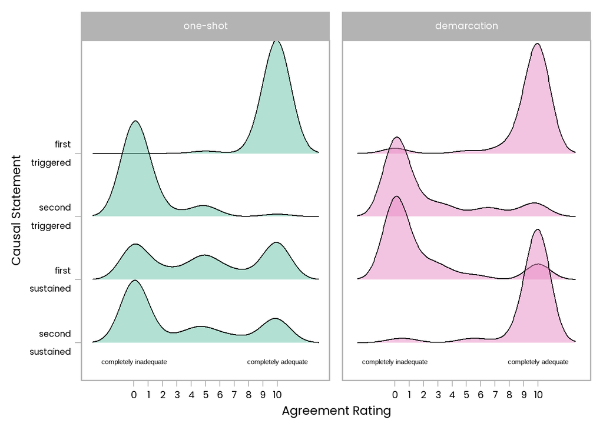

```r
library(ggridges)
g2 <- ggplot(tdata_long, aes(x = rating, y = entity, fill = structure)) +
  facet_grid( ~ structure)+
  scale_x_continuous(breaks = seq(0, 10, 1))+
  geom_density_ridges(alpha = 0.5)+
   #stat_summary(aes(x = rating_rec), fun.x=mean, geom="point",
  #             color = "black", shape = 22, size = 2, group=1, alpha = 1)+
  scale_fill_manual(values=c("#66c2a5", "#e78ac3", "#8da0cb", "#a6d854"))+
  #scale_fill_viridis_c(name = "Explanation \nRating", option = "C", breaks=c(-5,0,5), labels=c("narrow scope", "no preference", "broad scope"))+
  labs(x = "Agreement Rating", y = "Causal Statement") +
  scale_y_discrete(limits=rev)+
  myTheme+
  theme_light(base_family = "Poppins", base_size = 20)+
  theme(panel.grid = element_blank(), axis.text = element_text(colour ="black"))+
  theme(legend.position="none",
        legend.title=element_blank(),legend.key.width = unit(1.95, 'cm'))+
  theme(axis.text.y = element_text(size = 14, angle = 0))+
  annotate("text", y = 0.7, x = 0, label = c("completely inadequate"), angle = 0)+
  annotate("text", y = 0.7, x = 10, label = c("completely adequate"), angle = 0)

g2
```

```r
ggsave("results_dist.svg",width=12,height=5)
ggsave("results_dist.pdf",width=12,height=5)
```

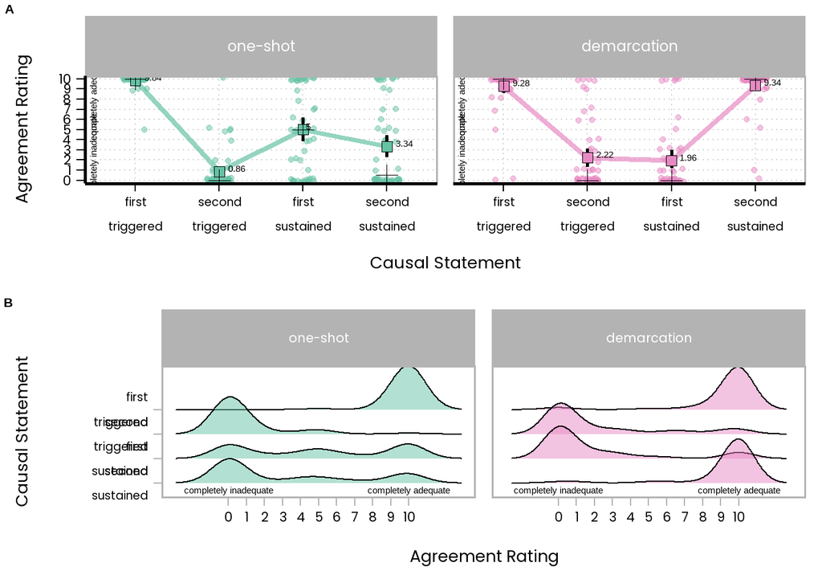

```r
library("ggpubr")

ggarrange(
  g, g2, labels = c("A", "B"),
  common.legend = TRUE, legend = "none",
  font.label = list(size = 16, color = "black", family = "Arial", face = "bold"),
  nrow = 2,
  ncol = 1
  ) -> c_plot

c_plot
```

```r
ggsave("res_squids_01.svg",width=11,height=12)
ggsave("res_squids_01.pdf",width=11,height=12)
```

# 4 Analyses

## 4.1 Mixed ANOVA

```r
library(afex)
library(emmeans)

a1 <- aov_car(rating ~ structure*entity + Error(subj_code/entity), tdata_long, anova_table = list(es = "pes"))
a1
```

```
## Anova Table (Type 3 tests)
##
## Response: rating
##             Effect           df   MSE          F  pes p.value
## 1        structure        1, 98  6.62  13.35 *** .120   <.001
## 2           entity 2.22, 217.72 12.43 132.80 *** .575   <.001
## 3 structure:entity 2.22, 217.72 12.43  39.73 *** .288   <.001
## ---
## Signif. codes:  0 '***' 0.001 '**' 0.01 '*' 0.05 '+' 0.1 ' ' 1
##
## Sphericity correction method: GG
```

Predicted interaction effect was significant-

Visualize also the obtained main effect of “structure” (reversibility)

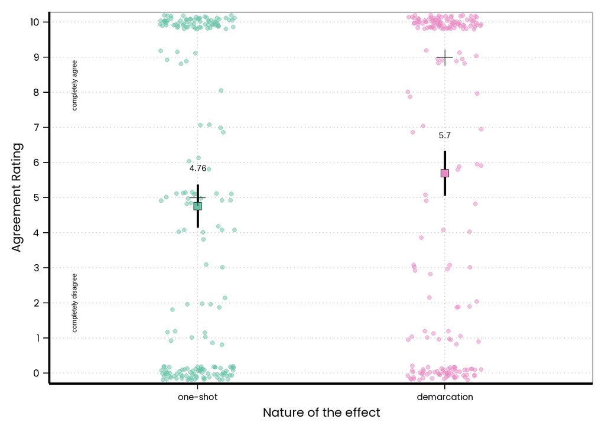

```r
tdata_sub <- tdata_long


library(see)
## first, turn sID into a factor
tdata_sub$subj_code <- factor(tdata_sub$subj_code)

pd <- position_dodge(width = 0.3)

tdata_sub$valueJitter <- jitter(tdata_sub$rating, factor = 0.01, amount = 0.004)

theme_set(theme_light(base_size = 20, base_family = "Poppins"))


g <- ggplot(tdata_sub, aes(x = structure, y = valueJitter)) +
  guides(fill=FALSE)+

  scale_y_continuous(limits = c(-0.3, 10.3), breaks=seq(0, 10, 1), expand = c(0,0)) +
  geom_jitter(aes(color = structure), alpha = 0.5, width = 0.15, height = 0.2) +
  stat_summary(aes(y = rating, group=1), fun.data = mean_cl_boot,
               geom = "errorbar", width = 0, size = 1) +
  stat_summary(aes(y = rating, group=1, fill = structure), fun.y=mean, geom="point",
               color = "black", shape = 22, size = 3, group=1, alpha = 1)+
  stat_summary(aes(y = rating,group=1), fun.y=median, geom="point", color = "black", shape = 3, size = 4,
               group=1, alpha = 1, position = position_dodge(width = 0.5))+
  labs(x = "Nature of the effect", y = "Agreement Rating") +
  scale_color_manual(name = "Strength",values=c("#66c2a5", "#e78ac3", "#8da0cb", "#a6d854"))+
  scale_fill_manual(name = "Strength",values=c("#66c2a5", "#e78ac3", "#8da0cb", "#a6d854"))+
  theme(legend.position = "none")+
  myTheme+
  theme(panel.grid.major = element_line(color = "lightgrey",
                                        size = 0.5,
                                        linetype = 'dotted'))+
  stat_summary(aes(label=round(after_stat(y),2)), fun.y=mean, geom="text", size=5,
             vjust = -6)+
  annotate("text", x = 0.5, y = 2, label = c("completely disagree"), angle = 90)+
  annotate("text", x = 0.5, y = 8.2, label = c("completely agree"), angle = 90)

g
```

Plot main effect of entity (causal statement):

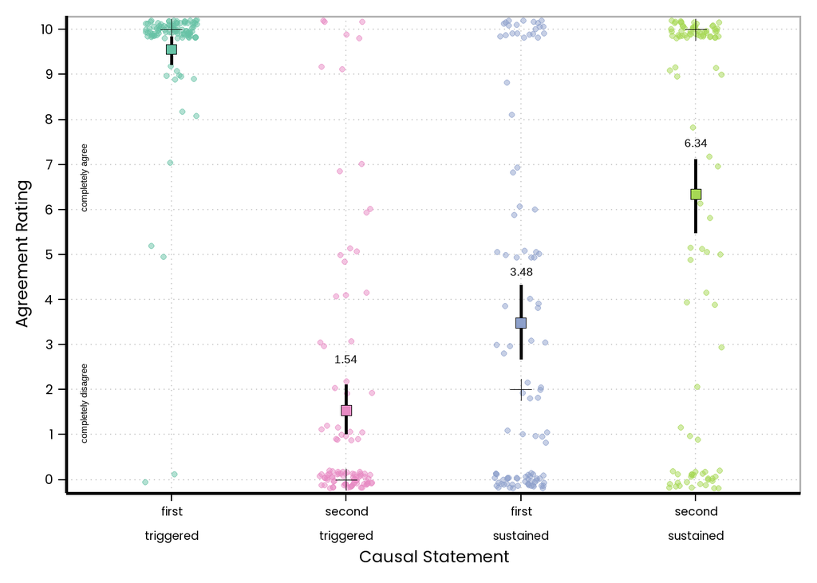

```r
tdata_sub <- tdata_long


library(see)
## first, turn sID into a factor
tdata_sub$subj_code <- factor(tdata_sub$subj_code)

pd <- position_dodge(width = 0.3)

tdata_sub$valueJitter <- jitter(tdata_sub$rating, factor = 0.01, amount = 0.004)

theme_set(theme_light(base_size = 20, base_family = "Poppins"))

g <- ggplot(tdata_sub, aes(x = entity, y = valueJitter)) +
  guides(fill=FALSE)+
  scale_y_continuous(limits = c(-0.3, 10.3), breaks=seq(0, 10, 1), expand = c(0,0)) +
  geom_jitter(aes(color = entity), alpha = 0.5, width = 0.15, height = 0.2) +
  stat_summary(aes(y = rating, group=1), fun.data = mean_cl_boot,
               geom = "errorbar", width = 0, size = 1) +
  stat_summary(aes(y = rating, group=1, fill = entity), fun.y=mean, geom="point",
               color = "black", shape = 22, size = 3, group=1, alpha = 1)+
  stat_summary(aes(y = rating,group=1), fun.y=median, geom="point", color = "black", shape = 3, size = 4,
               group=1, alpha = 1, position = position_dodge(width = 0.5))+
  labs(x = "Causal Statement", y = "Agreement Rating") +
  scale_color_manual(name = "Strength",values=c("#66c2a5", "#e78ac3", "#8da0cb", "#a6d854"))+
  scale_fill_manual(name = "Strength",values=c("#66c2a5", "#e78ac3", "#8da0cb", "#a6d854"))+
  theme(legend.position = "none")+
  annotate("text", x = 0.5, y = 1.7, label = c("completely disagree"), angle = 90)+
  annotate("text", x = 0.5, y = 6.7, label = c("completely agree"), angle = 90)+
  myTheme+
  theme(panel.grid.major = element_line(color = "lightgrey",
                                        size = 0.5,
                                        linetype = 'dotted'))+
  stat_summary(aes(label=round(after_stat(y),2)), fun.y=mean, geom="text", size=5,
             vjust = -6)

g
```

## 4.2 Contrasts

```r
library(lsmeans)
# means

ls2 <- lsmeans(a1, c("structure", "entity"))
ls2
```

```
##  structure   entity            lsmean    SE df lower.CL upper.CL
##  one-shot    first..triggered    9.84 0.224 98   9.3946    10.29
##  demarcation first..triggered    9.28 0.224 98   8.8346     9.73
##  one-shot    second..triggered   0.86 0.391 98   0.0833     1.64
##  demarcation second..triggered   2.22 0.391 98   1.4433     3.00
##  one-shot    first..sustained    5.00 0.524 98   3.9592     6.04
##  demarcation first..sustained    1.96 0.524 98   0.9192     3.00
##  one-shot    second..sustained   3.34 0.454 98   2.4397     4.24
##  demarcation second..sustained   9.34 0.454 98   8.4397    10.24
##
## Confidence level used: 0.95
```

```r
contrasts <- emmeans(a1, ~ entity|structure)
s <- pairs(contrasts, adjust = "none")


s
```

```
## structure = one-shot:
##  contrast                              estimate    SE df t.ratio p.value
##  first..triggered - second..triggered      8.98 0.472 98  19.024  <.0001
##  first..triggered - first..sustained       4.84 0.623 98   7.773  <.0001
##  first..triggered - second..sustained      6.50 0.469 98  13.862  <.0001
##  second..triggered - first..sustained     -4.14 0.630 98  -6.570  <.0001
##  second..triggered - second..sustained    -2.48 0.575 98  -4.316  <.0001
##  first..sustained - second..sustained      1.66 0.807 98   2.058  0.0423
##
## structure = demarcation:
##  contrast                              estimate    SE df t.ratio p.value
##  first..triggered - second..triggered      7.06 0.472 98  14.957  <.0001
##  first..triggered - first..sustained       7.32 0.623 98  11.757  <.0001
##  first..triggered - second..sustained     -0.06 0.469 98  -0.128  0.8984
##  second..triggered - first..sustained      0.26 0.630 98   0.413  0.6808
##  second..triggered - second..sustained    -7.12 0.575 98 -12.391  <.0001
##  first..sustained - second..sustained     -7.38 0.807 98  -9.148  <.0001
```

```r
confint(s, level = 0.95)
```

```
## structure = one-shot:
##  contrast                              estimate    SE df lower.CL upper.CL
##  first..triggered - second..triggered      8.98 0.472 98   8.0433    9.917
##  first..triggered - first..sustained       4.84 0.623 98   3.6044    6.076
##  first..triggered - second..sustained      6.50 0.469 98   5.5695    7.431
##  second..triggered - first..sustained     -4.14 0.630 98  -5.3905   -2.890
##  second..triggered - second..sustained    -2.48 0.575 98  -3.6203   -1.340
##  first..sustained - second..sustained      1.66 0.807 98   0.0591    3.261
##
## structure = demarcation:
##  contrast                              estimate    SE df lower.CL upper.CL
##  first..triggered - second..triggered      7.06 0.472 98   6.1233    7.997
##  first..triggered - first..sustained       7.32 0.623 98   6.0844    8.556
##  first..triggered - second..sustained     -0.06 0.469 98  -0.9905    0.871
##  second..triggered - first..sustained      0.26 0.630 98  -0.9905    1.510
##  second..triggered - second..sustained    -7.12 0.575 98  -8.2603   -5.980
##  first..sustained - second..sustained     -7.38 0.807 98  -8.9809   -5.779
##
## Confidence level used: 0.95
```

Get effect standardized effect sizes for the contrasts

First get the SDs that need to be pooled (and also the correlations between measures for the within-comparisons)

```r
library(dplyr)

tdata_long %>%
  group_by(structure, entity) %>%
  summarise_at(vars(rating), list(name=sd))
```

```
## # A tibble: 8 × 3
## # Groups:   structure [2]
##   structure   entity                name
##   <fct>       <fct>                <dbl>
## 1 one-shot    "first \ntriggered"  0.738
## 2 one-shot    "second \ntriggered" 1.98
## 3 one-shot    "first \nsustained"  4.07
## 4 one-shot    "second \nsustained" 4.04
## 5 demarcation "first \ntriggered"  2.12
## 6 demarcation "second \ntriggered" 3.38
## 7 demarcation "first \nsustained"  3.31
## 8 demarcation "second \nsustained" 2.06
```

```r
library(dplyr)

tdata_stable <- subset(tdata, structure == "one-shot")
tdata_unstable <- subset(tdata, structure == "demarcation")

tdata_stable %>%
  group_by(structure) %>%
  summarize(cor=cor(first_obj_caused_rating, second_obj_caused_rating))
```

```
## # A tibble: 1 × 2
##   structure    cor
##   <fct>      <dbl>
## 1 one-shot  -0.337
```

```r
tdata_unstable %>%
  group_by(structure) %>%
  summarize(cor=cor(first_obj_caused_rating, second_obj_caused_rating))
```

```
## # A tibble: 1 × 2
##   structure       cor
##   <fct>         <dbl>
## 1 demarcation -0.0658
```

```r
# using the functions from the MOTE package (see https://matthewbjane.quarto.pub/guide-to-effect-sizes-and-confidence-intervals/Standardized-Mean-Differences.html#sec-repeated-measures-drm)

library(MOTE)


# stable condition

# structure       entity             lsmean    SE df lower.CL upper.CL
# stable effect   first..caused        9.84 0.224 98   9.3946    10.29
# stable effect   second..caused       0.86 0.391 98   0.0833     1.64

# sds
#stable effect  first \ncaused  0.7384485
#stable effect  second \ncaused 1.9795897

#Cor
#irreversible   -0.1470522


stats <- d.dep.t.rm(
  m1 = 9.84,
  m2 = 0.86,
  sd1 = 0.7384485   ,
  sd2 = 1.9795897   ,
  n = 50,
  a = 0.05,
  r = -0.3367331
)
```

[output not shown]

```r
stats$estimate
```

```
## [1] "$d_{rm}$ = 6.29, 95\\% CI [5.02, 7.53]"
```

```r
# unstable condition

#structure    entity             lsmean    SE df lower.CL upper.CL
# unstable effect first..caused        9.28 0.224 98   8.8346     9.73
# unstable effect second..caused       2.22 0.391 98   1.4433     3.00

# sds
# unstable effect   first \ncaused  2.1192991
# unstable effect   second \ncaused 3.3763282

#Cor
#unstable   -0.06582681


stats <- d.dep.t.rm(
  m1 = 9.28,
  m2 = 2.22,
  sd1 = 2.1192991       ,
  sd2 = 3.3763282,
  n = 50,
  a = 0.05,
  r = -0.06582681
)

stats$estimate
```

```
## [1] "$d_{rm}$ = 2.51, 95\\% CI [1.94, 3.08]"
```

The final planned contrast compares the sustainer ratings for the second cause in “irreversible” and “reversible”. It must be looked up from the long list of contrasts below:

```r
contrasts <- emmeans(a1, ~ entity*structure)
s <- pairs(contrasts, adjust = "none")


s
```

```
##  contrast                                                      estimate    SE
##  (first..triggered one-shot) - (second..triggered one-shot)        8.98 0.472
##  (first..triggered one-shot) - (first..sustained one-shot)         4.84 0.623
##  (first..triggered one-shot) - (second..sustained one-shot)        6.50 0.469
##  (first..triggered one-shot) - first..triggered demarcation        0.56 0.317
##  (first..triggered one-shot) - second..triggered demarcation       7.62 0.451
##  (first..triggered one-shot) - first..sustained demarcation        7.88 0.570
##  (first..triggered one-shot) - second..sustained demarcation       0.50 0.506
##  (second..triggered one-shot) - (first..sustained one-shot)       -4.14 0.630
##  (second..triggered one-shot) - (second..sustained one-shot)      -2.48 0.575
##  (second..triggered one-shot) - first..triggered demarcation      -8.42 0.451
##  (second..triggered one-shot) - second..triggered demarcation     -1.36 0.554
##  (second..triggered one-shot) - first..sustained demarcation      -1.10 0.654
##  (second..triggered one-shot) - second..sustained demarcation     -8.48 0.599
##  (first..sustained one-shot) - (second..sustained one-shot)        1.66 0.807
##  (first..sustained one-shot) - first..triggered demarcation       -4.28 0.570
##  (first..sustained one-shot) - second..triggered demarcation       2.78 0.654
##  (first..sustained one-shot) - first..sustained demarcation        3.04 0.742
##  (first..sustained one-shot) - second..sustained demarcation      -4.34 0.693
##  (second..sustained one-shot) - first..triggered demarcation      -5.94 0.506
##  (second..sustained one-shot) - second..triggered demarcation      1.12 0.599
##  (second..sustained one-shot) - first..sustained demarcation       1.38 0.693
##  (second..sustained one-shot) - second..sustained demarcation     -6.00 0.642
##  first..triggered demarcation - second..triggered demarcation      7.06 0.472
##  first..triggered demarcation - first..sustained demarcation       7.32 0.623
##  first..triggered demarcation - second..sustained demarcation     -0.06 0.469
##  second..triggered demarcation - first..sustained demarcation      0.26 0.630
##  second..triggered demarcation - second..sustained demarcation    -7.12 0.575
##  first..sustained demarcation - second..sustained demarcation     -7.38 0.807
##  df t.ratio p.value
##  98  19.024  <.0001
##  98   7.773  <.0001
##  98  13.862  <.0001
##  98   1.764  0.0808
##  98  16.890  <.0001
##  98  13.813  <.0001
##  98   0.988  0.3256
##  98  -6.570  <.0001
##  98  -4.316  <.0001
##  98 -18.663  <.0001
##  98  -2.457  0.0158
##  98  -1.681  0.0960
##  98 -14.153  <.0001
##  98   2.058  0.0423
##  98  -7.502  <.0001
##  98   4.248  <.0001
##  98   4.098  0.0001
##  98  -6.258  <.0001
##  98 -11.736  <.0001
##  98   1.869  0.0646
##  98   1.990  0.0494
##  98  -9.352  <.0001
##  98  14.957  <.0001
##  98  11.757  <.0001
##  98  -0.128  0.8984
##  98   0.413  0.6808
##  98 -12.391  <.0001
##  98  -9.148  <.0001
```

```r
confint(s, level = 0.95)
```

```
##  contrast                                                      estimate    SE
##  (first..triggered one-shot) - (second..triggered one-shot)        8.98 0.472
##  (first..triggered one-shot) - (first..sustained one-shot)         4.84 0.623
##  (first..triggered one-shot) - (second..sustained one-shot)        6.50 0.469
##  (first..triggered one-shot) - first..triggered demarcation        0.56 0.317
##  (first..triggered one-shot) - second..triggered demarcation       7.62 0.451
##  (first..triggered one-shot) - first..sustained demarcation        7.88 0.570
##  (first..triggered one-shot) - second..sustained demarcation       0.50 0.506
##  (second..triggered one-shot) - (first..sustained one-shot)       -4.14 0.630
##  (second..triggered one-shot) - (second..sustained one-shot)      -2.48 0.575
##  (second..triggered one-shot) - first..triggered demarcation      -8.42 0.451
##  (second..triggered one-shot) - second..triggered demarcation     -1.36 0.554
##  (second..triggered one-shot) - first..sustained demarcation      -1.10 0.654
##  (second..triggered one-shot) - second..sustained demarcation     -8.48 0.599
##  (first..sustained one-shot) - (second..sustained one-shot)        1.66 0.807
##  (first..sustained one-shot) - first..triggered demarcation       -4.28 0.570
##  (first..sustained one-shot) - second..triggered demarcation       2.78 0.654
##  (first..sustained one-shot) - first..sustained demarcation        3.04 0.742
##  (first..sustained one-shot) - second..sustained demarcation      -4.34 0.693
##  (second..sustained one-shot) - first..triggered demarcation      -5.94 0.506
##  (second..sustained one-shot) - second..triggered demarcation      1.12 0.599
##  (second..sustained one-shot) - first..sustained demarcation       1.38 0.693
##  (second..sustained one-shot) - second..sustained demarcation     -6.00 0.642
##  first..triggered demarcation - second..triggered demarcation      7.06 0.472
##  first..triggered demarcation - first..sustained demarcation       7.32 0.623
##  first..triggered demarcation - second..sustained demarcation     -0.06 0.469
##  second..triggered demarcation - first..sustained demarcation      0.26 0.630
##  second..triggered demarcation - second..sustained demarcation    -7.12 0.575
##  first..sustained demarcation - second..sustained demarcation     -7.38 0.807
##  df lower.CL upper.CL
##  98  8.04326    9.917
##  98  3.60440    6.076
##  98  5.56950    7.431
##  98 -0.06985    1.190
##  98  6.72468    8.515
##  98  6.74789    9.012
##  98 -0.50441    1.504
##  98 -5.39048   -2.890
##  98 -3.62026   -1.340
##  98 -9.31532   -7.525
##  98 -2.45841   -0.262
##  98 -2.39868    0.199
##  98 -9.66901   -7.291
##  98  0.05907    3.261
##  98 -5.41211   -3.148
##  98  1.48132    4.079
##  98  1.56805    4.512
##  98 -5.71615   -2.964
##  98 -6.94441   -4.936
##  98 -0.06900    2.309
##  98  0.00385    2.756
##  98 -7.27317   -4.727
##  98  6.12326    7.997
##  98  6.08440    8.556
##  98 -0.99050    0.871
##  98 -0.99048    1.510
##  98 -8.26026   -5.980
##  98 -8.98093   -5.779
##
## Confidence level used: 0.95
```

The relevant contrast is: “second..sustained stable - second..sustained unstable”, which is significant.

Get effect size:

```r
#structure    entity             lsmean    SE df lower.CL upper.CL
# unstable effect second..sustained   9.34 0.454 98   8.4397    10.24
# stable effect   second..sustained   3.34 0.454 98   2.4397     4.24


#SDs
# unstable effect   second \nsustained  2.0564483
# stable effect second \nsustained  4.0436900


stats <- d.ind.t(
  m1 = 9.34,
  m2 = 3.34,
  sd1 = 2.0564483   ,
  sd2 = 4.0436900,
  n1 = 50,
  n2 = 50,
  a = 0.05
)

stats$estimate
```

```
## [1] "$d_s$ = 1.87, 95\\% CI [1.40, 2.34]"
```